# LBB9

Yvonne Lam

10/24/2019

# Report

Using unsupervised learning algorithms learnt (PCA and K-means), we can perform analysis to better understand the data we are working with. In this case, we are working with a leukemia dataset on the genetic profiles of a small sample size (72 patients). As there are too many variables (gene expressions), PCA is suitable to be used for reducing dimensions and still capture sufficient and significant information for making inferences. K-means is also suitable for making inferences by clustering cases to identify patterns within a dataset.

## Analysis

### Data Preparation

```r
#Read file
leukemia <- read.csv("leukemia.csv")

#Check structure
str(leukemia)
```

```
## 'data.frame':    3571 obs. of  72 variables:
##  $ ALL   : num  0.562 0.214 -0.637 0.347 0.546 ...
##  $ ALL.1 : num  -0.623 -0.912 -0.465 -0.734 -0.54 ...
##  $ ALL.2 : num  -0.815 -1.084 -0.583 1.786 1.445 ...
##  $ ALL.3 : num  0.229 -0.966 -0.525 -0.188 -0.535 ...
##  $ ALL.4 : num  -0.706 0.661 -0.548 -0.703 -0.286 ...
##  $ ALL.5 : num  -0.315 0.541 -0.156 0.446 -0.204 ...
##  $ ALL.6 : num  -0.0895 -0.9165 -0.4702 -1.0269 -0.6345 ...
##  $ ALL.7 : num  -0.6237 -0.9126 -0.4658 0.8609 0.0779 ...
##  $ ALL.8 : num  -0.816 1.564 -0.659 -0.276 0.127 ...
##  $ ALL.9 : num  2.044 0.45 -0.141 0.195 0.507 ...
##  $ ALL.10: num  -0.425 1.443 -0.267 -0.819 -1.187 ...
##  $ ALL.11: num  0.0732 -0.2865 0.2321 -0.3089 -1.6797 ...
##  $ ALL.12: num  -0.587 0.549 -0.429 0.389 0.577 ...
##  $ ALL.13: num  -0.668 -0.736 -0.511 0.178 1.854 ...
```

[output cut: 58 more lines]

```r
#t function to transpose dataframe, patient's gene expressions in a row instead of column
leu <- data.frame(t(leukemia))

#express patient leukemia outcome as a column (target variable)
leu$label <- rownames(leu)

#Trim label ALL and AML neatly, and convert to factor
leu$label <- strtrim(leu$label, 3)
leu$label <- as.factor(leu$label)

#Remove row names
rownames(leu) <- NULL

#Reconfirm the levels in label (ALL and AML)
levels(leu$label)
```

```
## [1] "ALL" "AML"
```

```r
#Tally the number of ALL and AML are the same as 47 ALL and 25 AML given.
table(leu$label)
```

```
##
## ALL AML
##  47  25
```

### PCA

```r
library(FactoMineR)
library(factoextra)
```

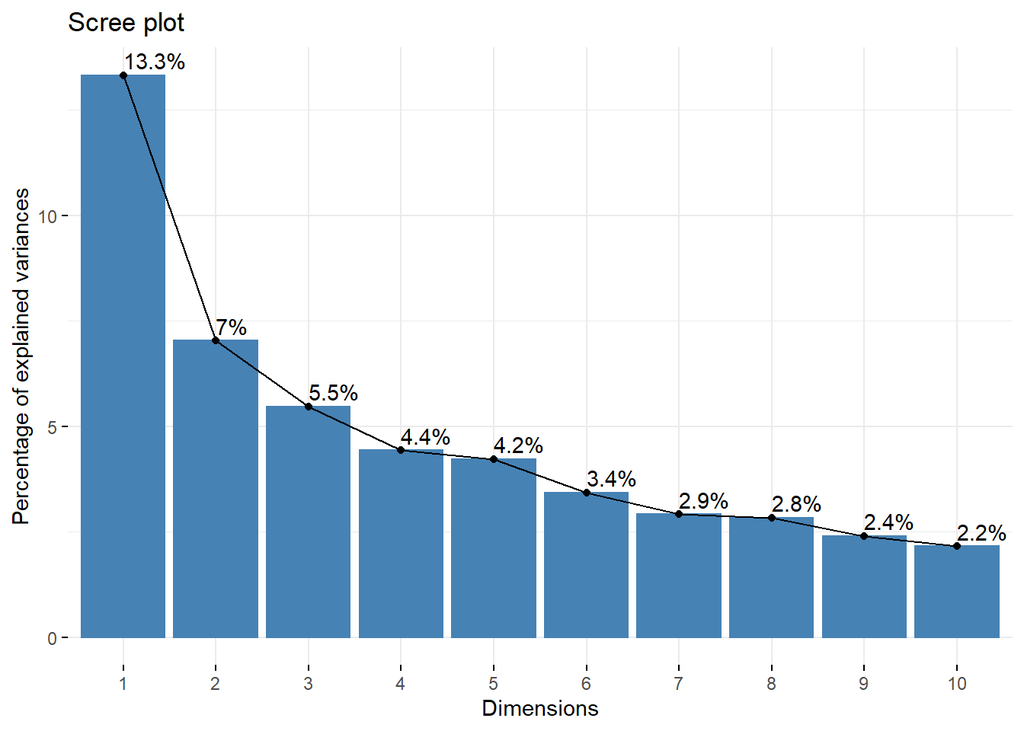

```r
#perform PCA
leu_pca <- PCA(leu[,-3572], graph = F)

#get eigen values
leu_eigen <- get_eigenvalue(leu_pca)

#screeplot; visualize eigen values
fviz_eig(leu_pca, addlabels = TRUE)  #choose n= 3 dimensions
```

Number of dimensions chosen is 3, as the first 3 dimensions contribute to 25.8% of total variance as per the screeplot.

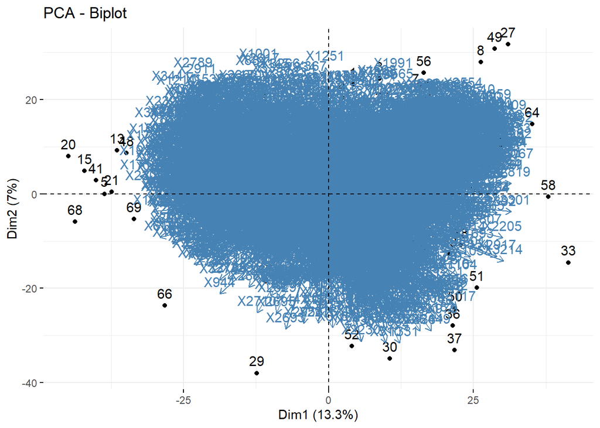

```r
#biplot
fviz_pca_biplot(leu_pca)
```

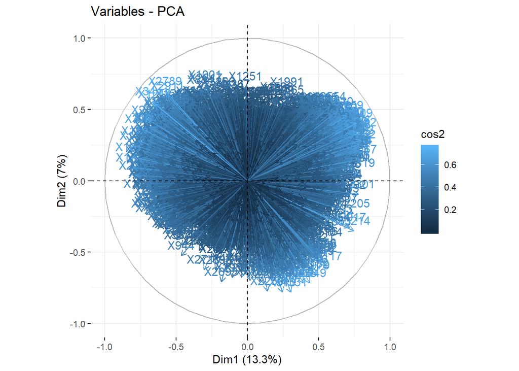

```r
#quality of representation
fviz_pca_var(leu_pca, col.var="cos2")
```

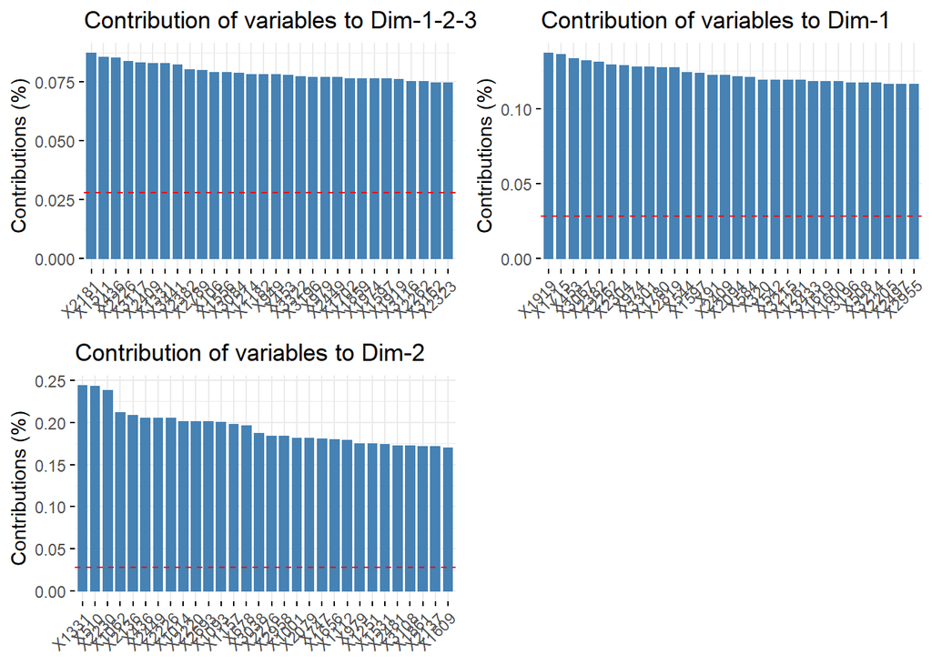

```r
#contributions of variables
c1 <- fviz_contrib(leu_pca, choice="var", top = 30, axes=1:3)
c2 <- fviz_contrib(leu_pca, choice="var", top = 30, axes=1)
c3 <- fviz_contrib(leu_pca, choice="var", top = 30, axes=2)
cowplot::plot_grid(c1,c2,c3)
```

The graph of variables show the relationship between variables and the quality of representation. The further away the variable is from the origin, the more well represented the variable is in the principal component. These well-represented variables can be identified in the Contribution of Variables graphs.

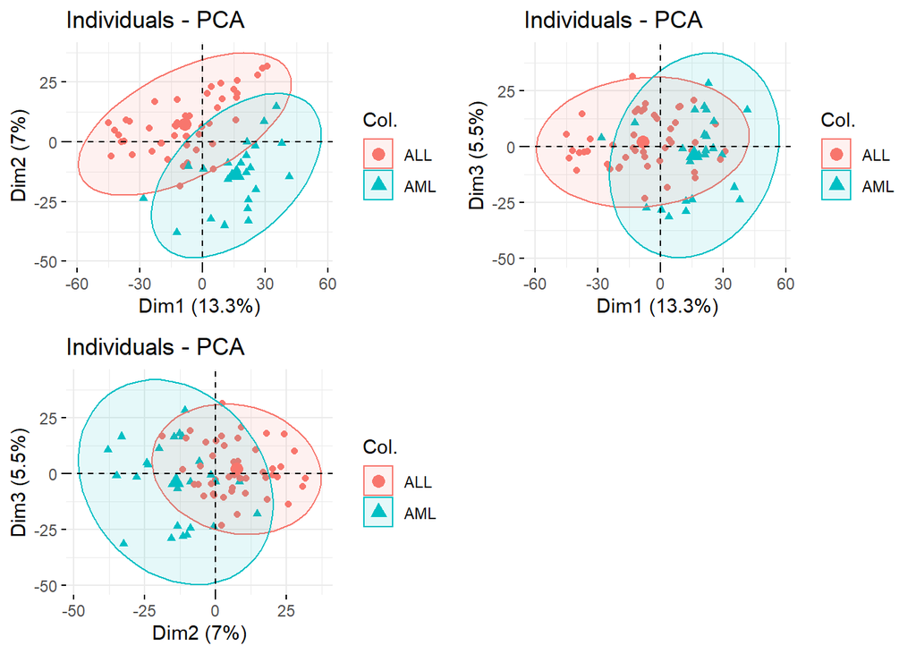

```r
#plot individual coordinates with PCA
f1 <- fviz_pca_ind(leu_pca, col.ind = leu[,3572], geom.ind = "point", addEllipses = T)
f2 <- fviz_pca_ind(leu_pca, col.ind = leu[,3572], geom.ind = "point", addEllipses = T, axes = c(1,3))
f3 <- fviz_pca_ind(leu_pca, col.ind = leu[,3572], geom.ind = "point", addEllipses = T, axes = c(2,3))

cowplot::plot_grid(f1,f2,f3)
```

The first graph of individuals shows that Dim 1 and Dim 2 are the best at separating the 2 groups of leukemia patients. The 2 groups have the smallest overlapping region in the first graph compared to the other 2 graphs.

### K-Means Clustering

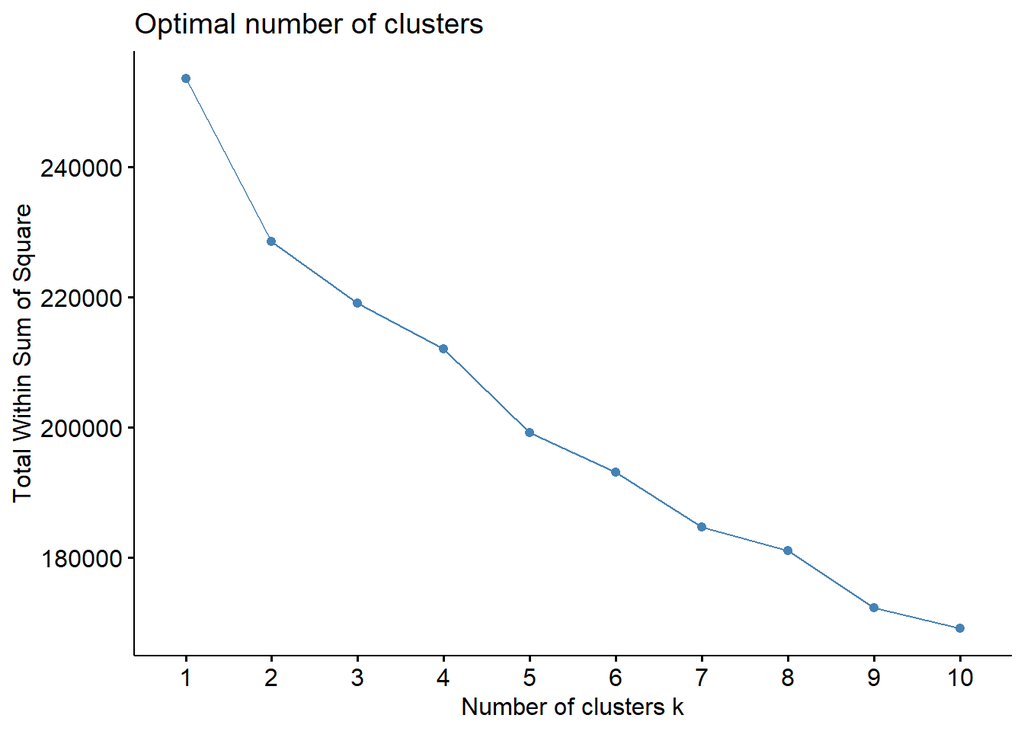

```r
#K-means clustering

#scale data
leu_scale <- scale(leu[,-3572])

#elbow method to determine no. of clusters to use
fviz_nbclust(leu_scale, kmeans, method = "wss")
```

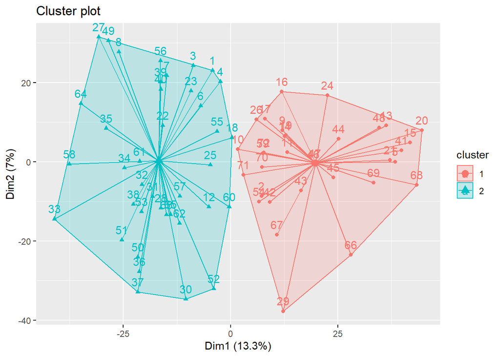

```r
#no. of clusters to use= 2 or 3, as the k is small and wss is also low

#perform kmeans
set.seed(345)
leu_km <- kmeans(leu_scale, 2, nstart=25)

#visualize clusters
fviz_cluster(object = leu_km, data = leu_scale, star.plot = T)
```

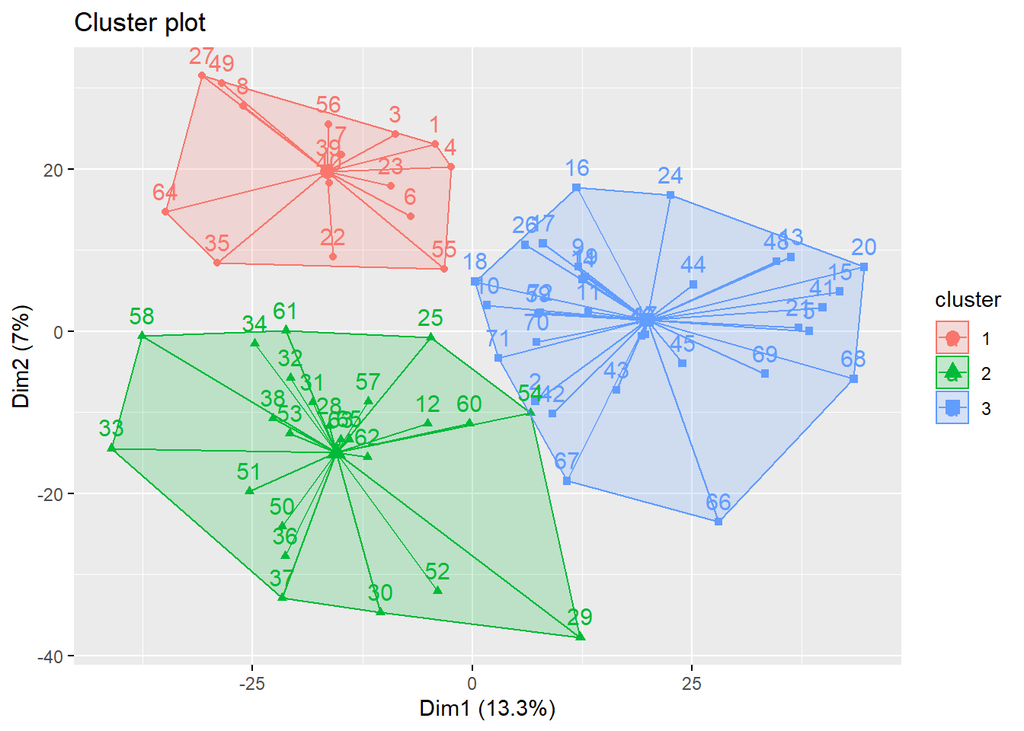

```r
#try no. of clusters = 3
leu_km3 <- kmeans(leu_scale, 3, nstart = 25)
fviz_cluster(object = leu_km3, data = leu_scale, star.plot = T)
```

When cluster number is 3, there are 3 distinct groups. However, the centroid for each cluster is not equally distanced from the individual cases (patients’ gene profile). On the other hand, when cluster number = 2, the centroids are fairly equidistant from all cases. Thus, k=2 is chosen.

## LBB Task

Learn-by-building  
Using both kmeans and PCA in unsupervised learning algorithms you’ve learned, produce a simple R markdown document where you demonstrate an exercise of both clustering and dimensionality reduction (PCA) on the leukemia.csv dataset.

The dataset contains 2 types of leukemia - acute lymphoblastic leukemia(ALL) and - acute myeloid leukemia (AML) with 3571 genetic expressions. There are 72 leukemia patients - 47 with “ALL” and 25 “AML”.

However, the genetic expression is arranged in rows, while the patients with ALL and AML are arranged in columns in the orginal dataset.

In order to extract the variability of the gene expression in PCA, data manipulation is required to transpose the genetic expression as columns and the patients as row first.

Use factoMiner and factoextRa packages to perform PCA and kmeans clustering to perform the above tasks.

You should include a series of visualisations learnt during this week and briefly explain your choice of parameters (how you choose k for k-means clustering, or how you choose to retain n number of dimensions for PCA) from the original data.

The data arises from the landmark Golub et al (1999) Science paper.

## Full Code

```r
#Read file
leukemia <- read.csv("leukemia.csv")

#Check structure
str(leukemia)
head(leukemia)

#t function to transpose dataframe, patient's gene expressions in a row instead of column
leu <- data.frame(t(leukemia))

#express patient leukemia outcome as a column (target variable)
leu$label <- rownames(leu)

#Trim label ALL and AML neatly, and convert to factor
leu$label <- strtrim(leu$label, 3)
leu$label <- as.factor(leu$label)

#Remove row names
rownames(leu) <- NULL

#Reconfirm the levels in label (ALL and AML)
levels(leu$label)

#Tally the number of ALL and AML are the same as 47 ALL and 25 AML given.
table(leu$label)


#PCA
library(FactoMineR)
library(factoextra)

#perform PCA
leu_pca <- PCA(leu[,-3572], graph = F)

#get eigen values
leu_eigen <- get_eigenvalue(leu_pca)

#screeplot; visualize eigen values
fviz_eig(leu_pca, addlabels = TRUE)
#choose n= 3 dimensions

#biplot
fviz_pca_biplot(leu_pca)

#quality of representation
fviz_pca_var(leu_pca, col.var="cos2")

#contributions of variables
c1 <- fviz_contrib(leu_pca, choice="var", top = 30, axes=1:3)
c2 <- fviz_contrib(leu_pca, choice="var", top = 30, axes=1)
c3 <- fviz_contrib(leu_pca, choice="var", top = 30, axes=2)
cowplot::plot_grid(c1,c2,c3)

#plot individual coordinates with PCA
f1 <- fviz_pca_ind(leu_pca, col.ind = leu[,3572], geom.ind = "point", addEllipses = T)
f2 <- fviz_pca_ind(leu_pca, col.ind = leu[,3572], geom.ind = "point", addEllipses = T, axes = c(1,3))
f3 <- fviz_pca_ind(leu_pca, col.ind = leu[,3572], geom.ind = "point", addEllipses = T, axes = c(2,3))

cowplot::plot_grid(f1,f2,f3)


#K-means clustering

#scale data
leu_scale <- scale(leu[,-3572])

#elbow method to determine no. of clusters to use
fviz_nbclust(leu_scale, kmeans, method = "wss")
#no. of clusters to use= 2 or 3, as the k is small and wss is also low

#perform kmeans
set.seed(345)
leu_km <- kmeans(leu_scale, 2, nstart=25)

#visualize clusters
fviz_cluster(object = leu_km, data = leu_scale, star.plot = T)

#try no. of clusters = 3
leu_km3 <- kmeans(leu_scale, 3, nstart = 25)
fviz_cluster(object = leu_km3, data = leu_scale, star.plot = T)
```

# Summary

In the above exercise, both PCA and K-means were used to visualise data. As there were data labels, we can see how the observations cluster. In PCA, there were no clear clusters in the graphs of individuals. In K-means however, there were distinct clusters. Another observation made is that with PCA, we can find out the variables which are influential on the outcome, whereas with K-means, we are not able to. Both methods have their merits when it comes to exploring data.

Unsupervised learning methods like PCA and K-means clustering can help us to visualise patterns in a dataset and come up with models to aid in clustering data. For high dimensional data or datasets with no target variable (labels), these methods become particularly useful when interpreting our data.